# WNN Time Series Forecasting

```r
library(OlivierBorot)
library(forecast)
library(ggplot2)
```

# Introduction

The **OlivierBorot** package implements the **Weighted Nearest Neighbors (WNN)** algorithm for time series forecasting, as described in Talavera-Llames et al. (2016). Please note there is also a French version of this vignette available here, named “WNN_FR.Rmd”

## Algorithm Overview

The WNN algorithm is a non-parametric method that:

1. **Extracts** the last `w` observations as a reference pattern
2. **Searches** through historical data to find similar patterns
3. **Identifies** the `k` nearest neighbors using Euclidean distance
4. **Combines** the future values following each neighbor using inverse-distance squared weighting

### Mathematical Formulation

Given a time series with values up to $c_i$, we want to predict the next $h$ values.

The reference window is:
$$CC_i =
[c_{i-w+1}, c_{i-w+2}, \ldots, c_i]$$

The Euclidean distance between patterns:
$$dist(i,j) = ||CC_i - CC_j||$$

The weighted forecast:
$$\hat{C}_i =
\frac{1}{\sum_{j=1}^{k} \alpha_j} \sum_{j=1}^{k} \alpha_j
C_{q_j}$$

where $\alpha_j = \frac{1}{dist(CC_{q_j}, CC_i)^2}$

# Example: AirPassengers Dataset

We will use the classic `AirPassengers` dataset to demonstrate the WNN algorithm.

## Data Exploration

```r
# Load the AirPassengers dataset
data(AirPassengers)

# Basic information
cat("Dataset: AirPassengers\n")
```

```
#> Dataset: AirPassengers
```

```r
cat("Length:", length(AirPassengers), "observations\n")
```

```
#> Length: 144 observations
```

```r
cat("Frequency:", frequency(AirPassengers), "(monthly)\n")
```

```
#> Frequency: 12 (monthly)
```

```r
cat("Period:", paste(start(AirPassengers), collapse = "-"), "to",
    paste(end(AirPassengers), collapse = "-"), "\n")
```

```
#> Period: 1949-1 to 1960-12
```

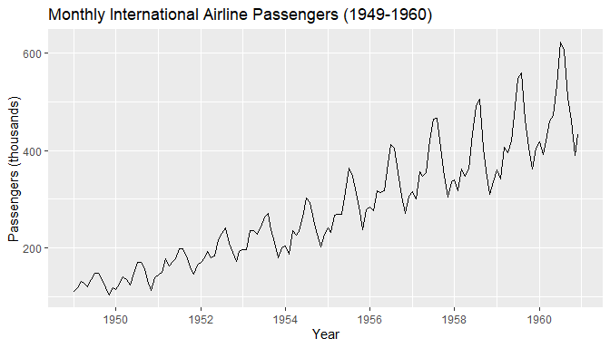

```r
# Plot the data
autoplot(AirPassengers) +
  ggtitle("Monthly International Airline Passengers (1949-1960)") +
  xlab("Year") +
  ylab("Passengers (thousands)")
```

## Train-Test Split

We’ll use the first 132 months for training and the last 12 months for testing.

```r
# Split data
train_end <- c(1959, 12)
train <- window(AirPassengers, end = train_end)
test <- window(AirPassengers, start = c(1960, 1))

cat("Training set:", length(train), "observations\n")
```

```
#> Training set: 132 observations
```

```r
cat("Test set:", length(test), "observations\n")
```

```
#> Test set: 12 observations
```

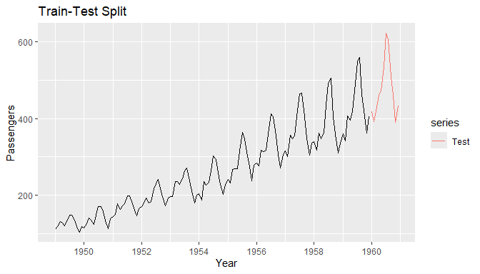

```r
# Plot split
autoplot(train) +
  autolayer(test, series = "Test") +
  ggtitle("Train-Test Split") +
  xlab("Year") +
  ylab("Passengers")
```

## WNN Model Training and Prediction

```r
# Create WNN model
# - horizon = 12 (predict 12 months)
# - window = 24 (use 24 months for pattern matching)
# - k = 5 (use 5 nearest neighbors)
wnn_model <- WNN$new(horizon = 12, window = 24, k = 5)

# Display model parameters
print(wnn_model)
```

```
#> WNN Model
#> ---------
#> Horizon (h): 12
#> Window (w):  24
#> Neighbors (k): 5
#> Status: Not fitted
```

```r
# Fit and predict
wnn_forecast <- wnn_model$fit_predict(train)

# Display complete summary
wnn_model$summary()
```

```
#> =======================================================
#>            WNN MODEL - COMPLETE SUMMARY
#> =======================================================
#>
#> >> HYPERPARAMETERS
#>    Horizon (h)     : 12 values to predict
#>    Window (w)      : 24 values for pattern matching
#>    Neighbors (k)   : 5 nearest neighbors
#>
#> >> STATUS: Model fitted
#>
#> >> ORIGINAL DATA
#>    Length          : 132 observations
#>    Min             : 104
#>    Max             : 559
#>    Mean            : 262.4924
#>    Std Dev         : 106.6258
#>    Frequency       : 12
#>    Start           : 1949-1
#>    End             : 1959-12
#>
#> >> NEAREST NEIGHBORS
#>    Distances       : 284.7244, 351.7698, 354.9958, 180.5132, 288.562
#>    Weights (alpha) : 0.1736, 0.1137, 0.1117, 0.4319, 0.169
#>
#> >> FORECAST (12 values)
#>    Start           : 1960-1
#>    Frequency       : 12
#>    Values          :
#>           Jan      Feb      Mar      Apr      May      Jun      Jul      Aug
#> 1960 345.1688 343.1199 371.0264 382.0721 399.8636 446.7056 507.6597 522.7384
#>           Sep      Oct      Nov      Dec
#> 1960 462.5560 397.2411 357.8446 370.3125
#>
#> =======================================================
```

## Results Visualization

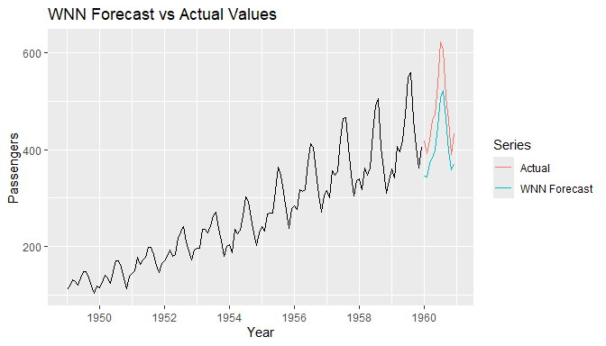

```r
# Plot forecast vs actual
autoplot(train) +
  autolayer(test, series = "Actual") +
  autolayer(wnn_forecast, series = "WNN Forecast") +
  ggtitle("WNN Forecast vs Actual Values") +
  xlab("Year") +
  ylab("Passengers") +
  guides(colour = guide_legend(title = "Series"))
```

## Forecast Accuracy

```r
# Calculate accuracy metrics
errors <- test - wnn_forecast

# Mean Absolute Error (MAE)
mae <- mean(abs(errors))

# Root Mean Square Error (RMSE)
rmse <- sqrt(mean(errors^2))

# Mean Absolute Percentage Error (MAPE)
mape <- mean(abs(errors / test)) * 100

cat("Forecast Accuracy Metrics:\n")
```

```
#> Forecast Accuracy Metrics:
```

```r
cat("-------------------------\n")
cat("MAE: ", round(mae, 2), "\n")
```

```
#> MAE:  67.31
```

```r
cat("RMSE:", round(rmse, 2), "\n")
```

```
#> RMSE: 70.69
```

```r
cat("MAPE:", round(mape, 2), "%\n")
```

```
#> MAPE: 13.94 %
```

# Comparison with Other Methods

Let’s compare WNN with traditional forecasting methods.

```r
# ETS model
ets_model <- ets(train)
ets_forecast <- forecast(ets_model, h = 12)

# ARIMA model
arima_model <- auto.arima(train)
arima_forecast <- forecast(arima_model, h = 12)

# Calculate RMSE for each method
rmse_wnn <- sqrt(mean((test - wnn_forecast)^2))
rmse_ets <- sqrt(mean((test - ets_forecast$mean)^2))
rmse_arima <- sqrt(mean((test - arima_forecast$mean)^2))

# Create comparison table
comparison <- data.frame(
  Method = c("WNN (k=5, w=24)", "ETS", "ARIMA"),
  RMSE = round(c(rmse_wnn, rmse_ets, rmse_arima), 2)
)

print(comparison)
```

```
#>            Method  RMSE
#> 1 WNN (k=5, w=24) 70.69
#> 2             ETS 27.40
#> 3           ARIMA 23.93
```

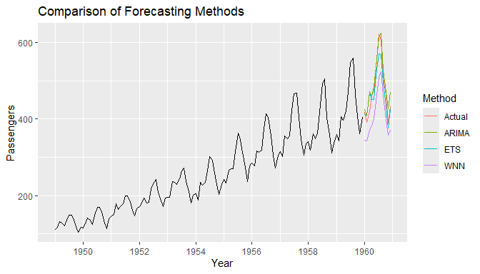

```r
# Visual comparison
autoplot(train) +
  autolayer(test, series = "Actual") +
  autolayer(wnn_forecast, series = "WNN") +
  autolayer(ets_forecast$mean, series = "ETS") +
  autolayer(arima_forecast$mean, series = "ARIMA") +
  ggtitle("Comparison of Forecasting Methods") +
  xlab("Year") +
  ylab("Passengers") +
  guides(colour = guide_legend(title = "Method"))
```

# Hyperparameter Sensitivity

Let’s explore how different hyperparameters affect the forecast.

## Effect of k (Number of Neighbors)

```r
k_values <- c(1, 3, 5, 7, 10)
results <- data.frame(k = integer(), RMSE = numeric())

for (k in k_values) {
  model <- WNN$new(horizon = 12, window = 24, k = k)
  pred <- model$fit_predict(train)
  rmse <- sqrt(mean((test - pred)^2))
  results <- rbind(results, data.frame(k = k, RMSE = rmse))
}

print(results)
```

```
#>    k     RMSE
#> 1  1 50.70832
#> 2  3 62.83187
#> 3  5 70.68636
#> 4  7 72.94597
#> 5 10 77.53678
```

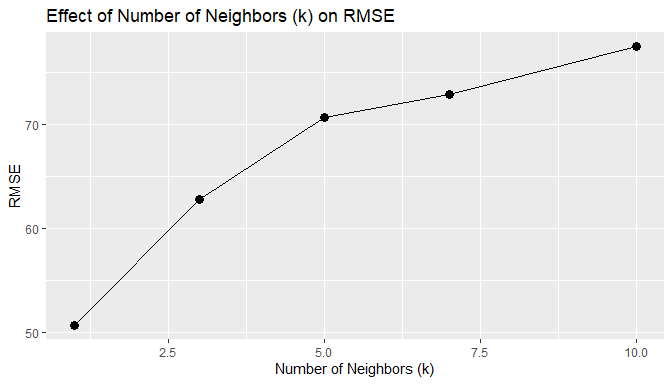

```r
ggplot(results, aes(x = k, y = RMSE)) +
  geom_line() +
  geom_point(size = 3) +
  ggtitle("Effect of Number of Neighbors (k) on RMSE") +
  xlab("Number of Neighbors (k)") +
  ylab("RMSE")
```

## Effect of Window Size (w)

```r
window_values <- c(12, 18, 24, 36, 48)
results_w <- data.frame(window = integer(), RMSE = numeric())

for (w in window_values) {
  model <- WNN$new(horizon = 12, window = w, k = 5)
  pred <- model$fit_predict(train)
  rmse <- sqrt(mean((test - pred)^2))
  results_w <- rbind(results_w, data.frame(window = w, RMSE = rmse))
}

print(results_w)
```

```
#>   window     RMSE
#> 1     12 75.34566
#> 2     18 72.10221
#> 3     24 70.68636
#> 4     36 66.57569
#> 5     48 66.56919
```

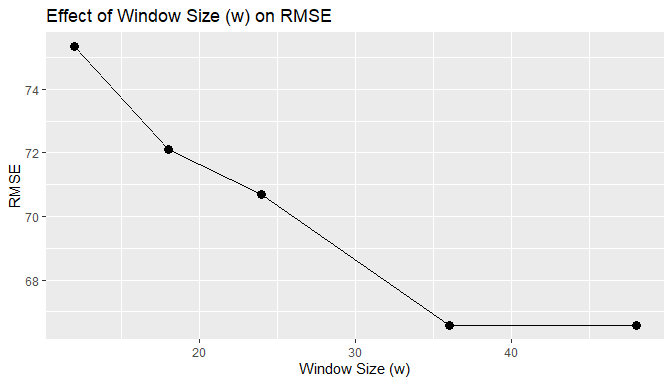

```r
ggplot(results_w, aes(x = window, y = RMSE)) +
  geom_line() +
  geom_point(size = 3) +
  ggtitle("Effect of Window Size (w) on RMSE") +
  xlab("Window Size (w)") +
  ylab("RMSE")
```

# Conclusion

**Strengths:**

- Easy to understand and implement
- No assumptions about data distribution
- Works well with recurring patterns
- Few hyperparameters to tune

**Considerations:**

- Computational cost increases with time series length
- Requires sufficient historical data
- Performance depends on pattern similarity in the data

## References

Talavera-Llames, R.L., Pérez-Chacón, R., Martínez-Ballesteros, M., Troncoso, A., Martínez-Álvarez, F. (2016). **A Nearest Neighbours-Based Algorithm for Big Time Series Data Forecasting**. In: Hybrid Artificial Intelligent Systems. HAIS 2016. Lecture Notes in Computer Science, vol 9648. Springer, Cham.